# HW3 report for MF 796

## U46881805

### 1. Option Pricing via FFT Techniques The Heston Model is defined by the following system of stochastic differential equations:

$$dS_t=rS_tdt+\sqrt{\nu_t}S_tdW_t^1$$$$d\nu_t=\kappa(\theta-\nu_t)dt+\sigma\sqrt{\nu_t}dW_t^2$$$$Cov(dW_t^1,dW_t^2)=\rho dt$$

### The characteristic function for the Heston Model is known to be:

$$\omega(u)=\dfrac{exp(iu\ln{S_0}+iu(r-q)t+\dfrac{\kappa\theta t(\kappa-i\rho\sigma u)}{\sigma^2})}{(\cosh{\dfrac{\lambda t}{2}}+\dfrac{\kappa-i\rho\sigma u}{\lambda}\sinh{\dfrac{\lambda t}{2}})^{\frac{2\kappa\theta}{\sigma^2}}}$$$$\Phi(u)=\omega(u)\exp{(\dfrac{-(u^2+iu)\nu_0}{\lambda\coth{\frac{\lambda t}{2}}+\kappa-i\rho\sigma u})}$$$$\lambda=\sqrt{\sigma^2(u^2+iu)+(\kappa-i\rho\sigma u)^2}$$

### Assume the risk-free rate is 2%, the initial asset price is 250 and that the asset pays no dividends

### (a) Exploring FFT Technique Parameters Consider a European Call Option with strike 250 expiring in six months. Additionally, assume you know that the parameters of the Heston Model are:

$$\sigma=0.2$$$$\mu_0=0.08$$$$\kappa=0.7$$$$\rho=-0.4$$$$\theta=0.1$$

#### i. Calculate the price of the European Call option with many values for the damping factor, α. What values of α seem to lead to the most stable price?

```python
import numpy as np
import pandas as pd
import matplotlib as mql
from pandas_datareader import data as pdr
import matplotlib.pyplot as plt
from numpy.random import standard_normal as stn
from datetime import datetime
from sklearn import linear_model
import statsmodels.api as sm
import scipy.stats as scs
from scipy.stats import norm
import math
from cvxopt import matrix, solvers
import scipy.optimize as sco
from scipy.fftpack import fft,ifft
from sympy import *

# function

def Riemamn_left(f,N,a,b):

    x=np.linspace(a,b,N+1)
    d=(b-a)/N
    w=0
    for i in x:
        if i!=b:
            w=w+f(i)*d

    return w

def Riemamn_mid(f,N,a,b):

    x=np.linspace(a,b,N+1)
    d=(b-a)/N
    w=0
    for i in x:
        if i!=b:
            w=w+f(i+d/2)*d

    return w


def Gauss_legendre(f,N,a,b):

    x,weight=np.polynomial.legendre.leggauss(N)
    x=x*(b - a) / 2 + (b + a) / 2

    w=0
    for i in range(N):
        w=w+weight[i]*f(x[i])*(b-a)/2

    return w



r=0.02
q=0
S0=250


# (a)

K=250
lk=np.log(K)
sigma=0.2
v0=0.08
k=0.7
rho=-0.4
theta=0.1

# i

j=complex(0,1)
t=1/2
alpha=1.5


def w(u):

    lambda1=np.sqrt(sigma**2*(u**2+j*u)+(k-j*rho*sigma*u)**2)

    A=np.exp(j*u*np.log(S0)+j*u*(r-q)*t+(k*theta*t*(k-j*rho*sigma*u))/(sigma**2))
    B=(np.cosh(lambda1*t/2)+(k-j*rho*sigma*u)/(lambda1)*np.sinh((lambda1*t/2)))**((2*k*theta)/(sigma**2))

    return A/B


def phi(u):

    lambda1 = np.sqrt(sigma ** 2 * (u ** 2 + j * u) + (k - j * rho * sigma * u) ** 2)
    C=np.exp(-((u**2+j*u)*v0)/(lambda1*np.cosh(lambda1*t/2)/(np.sinh(lambda1*t/2))+k-j*rho*sigma*u))

    return w(u)*C

def kesai(v):

    D=(np.exp(-r*t))/((alpha+j*v)*(alpha+j*v+1))

    return D*phi(v-(alpha+1)*j)

def f(v):

    return np.exp(-j*v*lk)*kesai(v)
```

```
21.268893053925794
1.1500000000000004
```

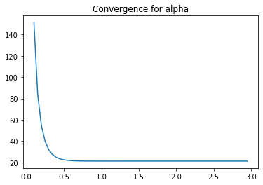

```python
lk=np.log(250)
r=0.02
q=0
S0=250


# (a)

K=250
lk=np.log(K)
sigma=0.2
v0=0.08
k=0.7
rho=-0.4
theta=0.1

# i

j=complex(0,1)
t=1/2
alpha=1.5
def pre_fft(N,K_1):
#     b = 1500
#     b=1500
    b=S0+S0*7*sigma

    dv = b / N
    dk = 2 * np.pi / b
    beta = np.log(S0) -  dk * N / 2
    vv = np.linspace(0, b, N+1)[0:-1]
    kk = np.linspace(0,N,N+1)[0:-1]*dk+beta

    x=[]
    for i in range(1,N+1):

        if i==1:
            delta=1
        else:
            delta=0

        a=((2-delta)*dv*np.exp(-r*t))/(2*(alpha+j*vv[i-1])*(alpha+j*vv[i-1]+1))
        b=np.exp(-j*(np.log(S0)-(dk*N/2))*vv[i-1])*phi(vv[i-1]-(alpha+1)*j)

        x.append(a*b)

    y = np.fft.fft(x)
    y_real = y.real
    CT = []
    for i in range(1, N + 1):
        aa = np.exp(-alpha * (np.log(S0) - dk * (N / 2 - (i - 1)))) / np.pi * y_real[i - 1]
        CT.append(aa)

    cc = np.interp(K_1, kk, CT)


    return [cc,kk]

N=2**10
[y,kk]=pre_fft(N,lk)
print(y)


aa=np.arange(0.1,3,0.05)
bb=[]
factor=1
for i in aa:
    N=2**10
    alpha=i
    [y,kk]=pre_fft(N,lk)
    bb.append(y)


    if np.size(bb)>=2:
        if np.abs(bb[-1]-bb[-2])<=10**(-3) and factor==1:

            alpha_stable=i
            factor=0

print(alpha_stable)








plt.title('Convergence for alpha')
plt.plot(aa,bb)
plt.show()
```

When $b=S_0+S_0*7*\sigma$.If $\alpha>1.15$,It will be the most stable

```
21.28493339629151
1.8000000000000007
```

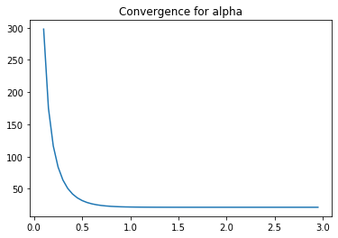

```python
lk=np.log(250)
r=0.02
q=0
S0=250


# (a)

K=250
lk=np.log(K)
sigma=0.2
v0=0.08
k=0.7
rho=-0.4
theta=0.1

# i

j=complex(0,1)
t=1/2
alpha=1.5
def pre_fft(N,K_1):
#     b = 1500
    b=1000
#     b=S0+S0*7*sigma

    dv = b / N
    dk = 2 * np.pi / b
    beta = np.log(S0) -  dk * N / 2
    vv = np.linspace(0, b, N+1)[0:-1]
    kk = np.linspace(0,N,N+1)[0:-1]*dk+beta

    x=[]
    for i in range(1,N+1):

        if i==1:
            delta=1
        else:
            delta=0

        a=((2-delta)*dv*np.exp(-r*t))/(2*(alpha+j*vv[i-1])*(alpha+j*vv[i-1]+1))
        b=np.exp(-j*(np.log(S0)-(dk*N/2))*vv[i-1])*phi(vv[i-1]-(alpha+1)*j)

        x.append(a*b)

    y = np.fft.fft(x)
    y_real = y.real
    CT = []
    for i in range(1, N + 1):
        aa = np.exp(-alpha * (np.log(S0) - dk * (N / 2 - (i - 1)))) / np.pi * y_real[i - 1]
        CT.append(aa)

    cc = np.interp(K_1, kk, CT)


    return [cc,kk]

N=2**10
[y,kk]=pre_fft(N,lk)
print(y)


aa=np.arange(0.1,3,0.05)
bb=[]
factor=1
for i in aa:
    N=2**10
    alpha=i
    [y,kk]=pre_fft(N,lk)
    bb.append(y)


    if np.size(bb)>=2:
        if np.abs(bb[-1]-bb[-2])<=10**(-3) and factor==1:

            alpha_stable=i
            factor=0

print(alpha_stable)








plt.title('Convergence for alpha')
plt.plot(aa,bb)
plt.show()
```

When $b=1000$.If $\alpha>1.8$,It will be the most stable

#### ii. Using the results above, choose a reasonable value of α and calculate the price of the same European Call with various values of N and ∆k (or equivalently N and B). Comment on what values seem to lead to the most accurate prices, and the efficiency of each parameterization.

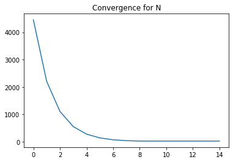

```python
NN=[]
YY=[]
lk=np.log(250)
for i in range(15):
    N=2**i
    NN.append(N)

    [y,kk]=pre_fft(N,lk)
    YY.append(y)

plt.title('Convergence for N')
plt.plot(range(15),YY)
plt.show()
```

#### iii. Calculate the price of a European Call with strike 260 using various values of N and ∆k (or N and B). Do the same sets of values for N, B and ∆k produce the best results? Comment on any differences that arise

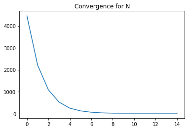

```python
lk=np.log(260)
NN=[]
YY=[]
for i in range(15):
    N=2**i
    NN.append(N)

    [y,kk]=pre_fft(N,lk)
    YY.append(y)

plt.title('Convergence for N')
plt.plot(range(15),YY)
plt.show()
```

I think this values of N,B and ∆k produce the best results

### (b) Exploring Heston Parameters Assume the risk-free rate is 2.5%, the initial asset price is 150 and that the asset pays no dividends.

$$\sigma=0.4$$$$\mu_0=0.09$$$$\kappa=0.5$$$$\rho=0.25$$$$\theta=0.12$$

#### i. Using these parameters, calculate Heston Model prices for three-month options at a range of strikes and extract the implied volatilities for each strike. Plot the implied volatility σ(K) as a function of strike.

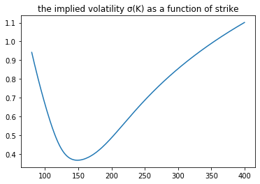

```python
r=0.025
q=0
S0=150


# (b)


sigma=0.4
v0=0.09
k=0.5
rho=0.25
theta=0.12

# i

j=complex(0,1)
t=1/4
alpha=1


N=2**10


def pre_fft_2(N,K_1):
    b = 1500

    dv = b / N
    dk = 2 * np.pi / b
    beta = np.log(S0) -  dk * N / 2
    vv = np.linspace(0, b, N+1)[0:-1]
    kk = np.linspace(0,N,N+1)[0:-1]*dk+beta

    x=[]
    for i in range(1,N+1):

        if i==1:
            delta=1
        else:
            delta=0

        a=((2-delta)*dv*np.exp(-r*t))/(2*(alpha+j*vv[i-1])*(alpha+j*vv[i-1]+1))
        b=np.exp(-j*(np.log(S0)-(dk*N/2))*vv[i-1])*phi(vv[i-1]-(alpha+1)*j)

        x.append(a*b)

    y = np.fft.fft(x)
    y_real = y.real
    CT = []
    for i in range(1, N + 1):
        aa = np.exp(-alpha * (np.log(S0) - dk * (N / 2 - (i - 1)))) / np.pi * y_real[i - 1]
        CT.append(aa)

    cc = np.interp(K_1, kk, CT)

    return cc


lk=np.log(250)
cc=pre_fft_2(N,lk)
K_2=np.arange(80,400,0.1)
llk=np.log(K_2)
ccc=pre_fft_2(N,llk)
















# KK=np.exp(kk)
#
# K_1=np.arange(0.1,np.log(250),0.01)
#
# cc = np.interp(K_1, kk, y)
#
#
#
#
#
#
#
# black-scholes
T=t

def BL(vol,K):

    d1 = (np.log(S0 / K) + (r + vol ** 2 / 2) * T) / (vol * np.sqrt(T))
    d2 = (np.log(S0 / K) + (r - vol ** 2 / 2) * T) / (vol * np.sqrt(T))
    c = S0 * norm.cdf(d1) - K * np.exp(-r * T) * norm.cdf(d2)

    return c
#
#
#
def dichotomy(K_K,y_y):

    cc=[]
    for i in range(np.size(K_K)):
        c=y_y[i]
        c_est=0
        floor=0
        top=5
        vol=(floor+top)/2

        while abs(c-c_est)>10**(-8):

            c_est=BL(vol,np.exp(K_K[i]))
            # print(c_est)
            if c-c_est>0:
                floor=vol
                vol=(vol+top)/2
            else:
                top=vol
                vol=(vol+floor)/2

        cc.append(vol)


    return cc
#
vol1=dichotomy(llk,ccc)
plt.title("the implied volatility σ(K) as a function of strike")
plt.plot(K_2,vol1)
plt.show()
```

I will choose b= 1500 to make the picture better.

#### ii. Use the FFT pricing technique to obtain prices of 150 strike calls at many expiries.Extract the implied volatility for each and plot the term structure of volatility by plotting time to expiry on the x-axis and implied volatility on the y-axis.

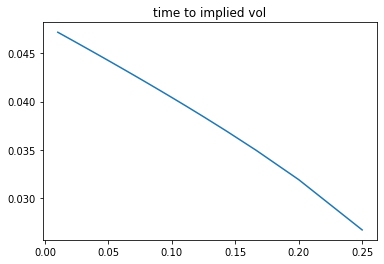

```python
r=0.025
q=0
S0=150


# (b)


sigma=0.4
v0=0.09
k=0.5
rho=0.25
theta=0.12

# i

j=complex(0,1)
t=1/4
alpha=1


N=2**10


def pre_fft_2(N,K_1):
    b = 2000


    dv = b / N
    dk = 2 * np.pi / b
    beta = np.log(S0) -  dk * N / 2
    vv = np.linspace(0, b, N+1)[0:-1]
    kk = np.linspace(0,N,N+1)[0:-1]*dk+beta

    x=[]
    for i in range(1,N+1):

        if i==1:
            delta=1
        else:
            delta=0

        a=((2-delta)*dv*np.exp(-r*t))/(2*(alpha+j*vv[i-1])*(alpha+j*vv[i-1]+1))
        b=np.exp(-j*(np.log(S0)-(dk*N/2))*vv[i-1])*phi(vv[i-1]-(alpha+1)*j)

        x.append(a*b)

    y = np.fft.fft(x)
    y_real = y.real
    CT = []
    for i in range(1, N + 1):
        aa = np.exp(-alpha * (np.log(S0) - dk * (N / 2 - (i - 1)))) / np.pi * y_real[i - 1]
        CT.append(aa)

    cc = np.interp(K_1, kk, CT)

    return cc


lk=np.log(150)
cc=pre_fft_2(N,lk)
K_2=np.arange(100,400,0.1)
llk=np.log(K_2)
K=150
ccc=pre_fft_2(N,K)

c_t=[]
tt=[]
for i in range(4,100):
    t=1/i
    tt.append(t)
    ctc = pre_fft_2(N, K)
    c_t.append(ctc)





def BL(vol,T):

    d1 = (np.log(S0 / K) + (r + vol ** 2 / 2) * T) / (vol * np.sqrt(T))
    d2 = (np.log(S0 / K) + (r - vol ** 2 / 2) * T) / (vol * np.sqrt(T))
    c = S0 * norm.cdf(d1) - K * np.exp(-r * T) * norm.cdf(d2)

    return c
#
#
#


def dichotomy(T_T,y_y):

    cc=[]
    for i in range(np.size(T_T)):
        c=y_y[i]
        c_est=0
        floor=0
        top=5
        vol=(floor+top)/2


        while abs(c-c_est)>10**(-8):
            # print(vol)
            c_est=BL(vol,np.exp(T_T[i]))
            # print(c_est)
            if c-c_est>0:
                floor=vol
                vol=(vol+top)/2
            else:
                top=vol
                vol=(vol+floor)/2

        cc.append(vol)


    return cc
#
vol1=dichotomy(tt,c_t)
plt.title('time to implied vol')
plt.plot(tt,vol1)
plt.show()
```

#### iii. Holding all other para|meters constant, vary each of the model parameters and plot the updated volatility skews and term structures. Comment on the impact that each parameter has on the skew and term structure.

##### Change $v_0$

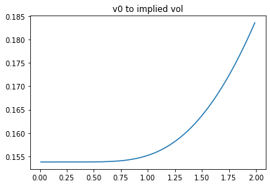

```python
r=0.025
q=0
S0=150


# (b)


sigma=0.4
v0=0.09
k=0.5
rho=0.25
theta=0.12

# i

j=complex(0,1)
t=1/4
alpha=1


N=2**10


def pre_fft_2(N,K_1):
    b = 2000


    dv = b / N
    dk = 2 * np.pi / b
    beta = np.log(S0) -  dk * N / 2
    vv = np.linspace(0, b, N+1)[0:-1]
    kk = np.linspace(0,N,N+1)[0:-1]*dk+beta

    x=[]
    for i in range(1,N+1):

        if i==1:
            delta=1
        else:
            delta=0

        a=((2-delta)*dv*np.exp(-r*t))/(2*(alpha+j*vv[i-1])*(alpha+j*vv[i-1]+1))
        b=np.exp(-j*(np.log(S0)-(dk*N/2))*vv[i-1])*phi(vv[i-1]-(alpha+1)*j)

        x.append(a*b)

    y = np.fft.fft(x)
    y_real = y.real
    CT = []
    for i in range(1, N + 1):
        aa = np.exp(-alpha * (np.log(S0) - dk * (N / 2 - (i - 1)))) / np.pi * y_real[i - 1]
        CT.append(aa)

    cc = np.interp(K_1, kk, CT)

    return cc


lk=np.log(150)
cc=pre_fft_2(N,lk)
K_2=np.arange(100,400,0.1)
llk=np.log(K_2)
K=150
ccc=pre_fft_2(N,K)

c_t=[]
tt=[]
it=range(4,100)
iv0=np.arange(0.01,2,0.01)

for i in iv0:
    v0=i
    ctc = pre_fft_2(N, K)
    c_t.append(ctc)




T=1/4
def BL(vol):

    d1 = (np.log(S0 / K) + (r + vol ** 2 / 2) * T) / (vol * np.sqrt(T))
    d2 = (np.log(S0 / K) + (r - vol ** 2 / 2) * T) / (vol * np.sqrt(T))
    c = S0 * norm.cdf(d1) - K * np.exp(-r * T) * norm.cdf(d2)

    return c
#
#
#


def dichotomy(T_T,y_y):

    cc=[]
    for i in range(np.size(T_T)):
        c=y_y[i]
        c_est=0
        floor=0
        top=5
        vol=(floor+top)/2


        while abs(c-c_est)>10**(-8):
            # print(vol)
            c_est=BL(vol)
            # print(c_est)
            if c-c_est>0:
                floor=vol
                vol=(vol+top)/2
            else:
                top=vol
                vol=(vol+floor)/2

        cc.append(vol)


    return cc
#
vol1=dichotomy(iv0,c_t)
plt.title('v0 to implied vol')
plt.plot(iv0,vol1)
plt.show()
```

##### Change $\kappa$

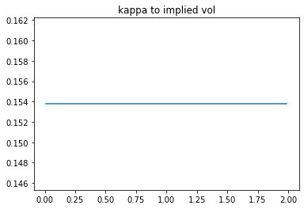

```python
r=0.025
q=0
S0=150


# (b)


sigma=0.4
v0=0.09
k=0.5
rho=0.25
theta=0.12

# i

j=complex(0,1)
t=1/4
alpha=1


N=2**10


def pre_fft_2(N,K_1):
    b = 2000


    dv = b / N
    dk = 2 * np.pi / b
    beta = np.log(S0) -  dk * N / 2
    vv = np.linspace(0, b, N+1)[0:-1]
    kk = np.linspace(0,N,N+1)[0:-1]*dk+beta

    x=[]
    for i in range(1,N+1):

        if i==1:
            delta=1
        else:
            delta=0

        a=((2-delta)*dv*np.exp(-r*t))/(2*(alpha+j*vv[i-1])*(alpha+j*vv[i-1]+1))
        b=np.exp(-j*(np.log(S0)-(dk*N/2))*vv[i-1])*phi(vv[i-1]-(alpha+1)*j)

        x.append(a*b)

    y = np.fft.fft(x)
    y_real = y.real
    CT = []
    for i in range(1, N + 1):
        aa = np.exp(-alpha * (np.log(S0) - dk * (N / 2 - (i - 1)))) / np.pi * y_real[i - 1]
        CT.append(aa)

    cc = np.interp(K_1, kk, CT)

    return cc


lk=np.log(150)
cc=pre_fft_2(N,lk)
K_2=np.arange(100,400,0.1)
llk=np.log(K_2)
K=150
ccc=pre_fft_2(N,K)

c_t=[]
tt=[]
it=range(4,100)
iv0=np.arange(0.01,2,0.01)
ikappa=np.arange(0.01,2,0.01)

for i in ikappa:
    k=i
    ctc = pre_fft_2(N, K)
    c_t.append(ctc)




T=1/4
def BL(vol):

    d1 = (np.log(S0 / K) + (r + vol ** 2 / 2) * T) / (vol * np.sqrt(T))
    d2 = (np.log(S0 / K) + (r - vol ** 2 / 2) * T) / (vol * np.sqrt(T))
    c = S0 * norm.cdf(d1) - K * np.exp(-r * T) * norm.cdf(d2)

    return c
#
#
#


def dichotomy(T_T,y_y):

    cc=[]
    for i in range(np.size(T_T)):
        c=y_y[i]
        c_est=0
        floor=0
        top=5
        vol=(floor+top)/2


        while abs(c-c_est)>10**(-8):
            # print(vol)
            c_est=BL(vol)
            # print(c_est)
            if c-c_est>0:
                floor=vol
                vol=(vol+top)/2
            else:
                top=vol
                vol=(vol+floor)/2

        cc.append(vol)


    return cc
#
vol1=dichotomy(ikappa,c_t)
plt.title('kappa to implied vol')
plt.plot(ikappa,vol1)
plt.show()
```